# Including Antibody Covariates in CTOT Aim 2: Scaled Difference of Log Antibodies

Frances Hung

Biostatistics, Epidemiology and Research Design (BERD) Core

Center for Human Systems Immunology (CHSI)

2023-01-24

# 1 Introduction

Out of our 44 Aim 2 patients, 20 have pre-transplant antibody data. The antibody study that Melissa Harnois and Richard Barfield ran only showed associations between pre-transplant antibody measures and CMV redevelopment, but we are more interested in seeing how much the covariates improve the COMPASS algorithm’s ability to predict changes in cell type expression. There are 16 antibody measures with complete data for the 20 patients. We exclude the italicized antibodies for correlation reasons explained later.

- AUC (IgG Whole Virion ELISA) (Area Under Curve.x)
- AUC (gB-AD2 ELISA) (Area Under Curve.y)
- CMV-specific IgG1 Concentration (IgG Whole Virion Subclass ELISA)
- CMV-specific IgG2 Concentration (IgG Whole Virion Subclass ELISA)
- CMV-specific IgG3 concentration (IgG Whole Virion Subclass ELISA)
- *CMV-specific IgG4 Concentration (IgG Whole Virion Subclass ELISA)*
- Avidity (IgG Whole Virion ELISA)
- gB Ectodomain (MFI) (BAMA)
- Pentameric Complex (PC) (BAMA)
- *gH/gL (BAMA)*
- *gH/gL/gO (MFI) (BAMA)*
- ID50 (ARPE neutralization)
- ID50 with complement (HFF neutralization)
- *ID50 without complement (HFF neutralization)*
- OD450 nm (IgM Whole Virion ELISA)
- Phagocytosis Score (ADCP)
- *Whole AD169r Virion Phagocytosis (ADCP)*

The antibody variables of interest found from Melissa’s project or deemed of interest in the pre-transplant stage are:

- PC
- gH/gL
- ID50 for ARPE neutralization
- CMV-specific IgG3 concentration)
- IgG Whole Virion ELISA “Area Under Curve” variable

In this report, we run original COMPASS and COMPASS-covariate on the 20 patients using different ways of excluding flow gates.

## 1.1 Logging/Scaling Antibody Measures

We first transform antibody measures into more usable covariates. In this notebook, we use the scaled difference of the logs of antibody measures at pre-transplant and at 2-3 months.

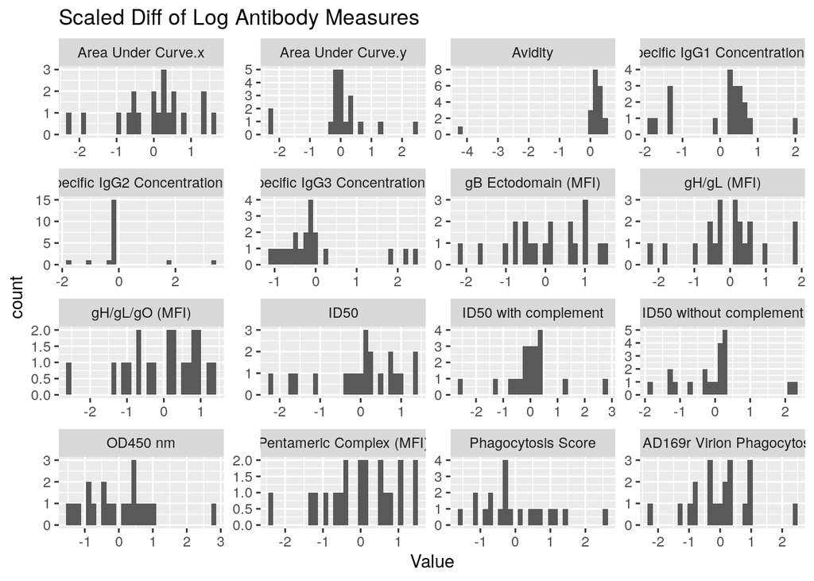

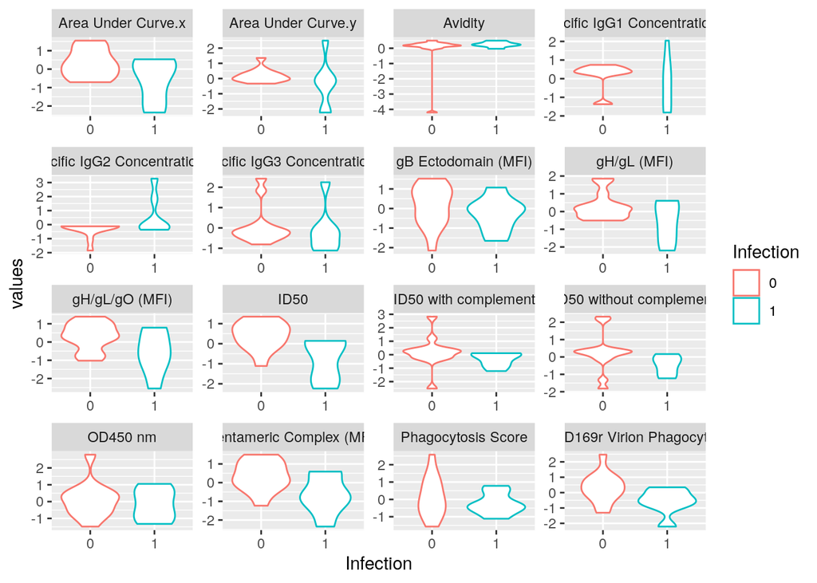

## 1.2 Covariate Correlation

To further define our antibody covariate matrix, we get rid of mostly missing covariates and some correlated covariates then add age as a covariate, saving as the dataframe “antibodyDF_diffs”.

Based on Richard’s analysis and the correlation plot below, we can get rid of a few antibodies and add in age as a covariate.

- gH/gL becomes either gH/gL/gO or Pentamer (MFI), which are glycoprotein complexes that antibodies target. Getting rid of gH/gL makes sense then, and gH/gL/gO and Pentamer appear to share similar correlation patterns. Out of these three, I keep only Pentamer.
- Richard excludes ID50 without complement (which is related to ID50 with complement and ID50), so I do the same.
- Richard excludes Whole AD169r Virion Phagocytosis (ADCP) (which is related to Phagocytosis Score), so I do the same.

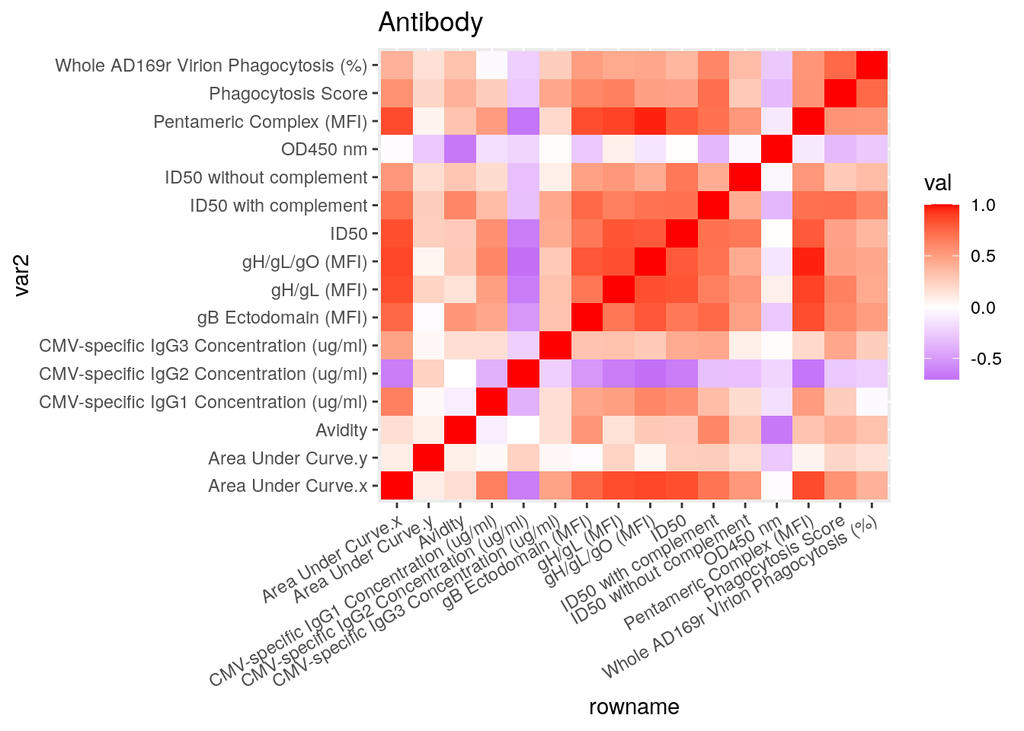

| TheID | Visit | Area Under Curve.x | Avidity | gB Ectodomain (MFI) | Pentameric Complex (MFI) | ID50 | ID50 with complement | Phagocytosis Score | Area Under Curve.y | OD450 nm | CMV-specific IgG1 Concentration (ug/ml) | CMV-specific IgG2 Concentration (ug/ml) | CMV-specific IgG3 Concentration (ug/ml) | AGE |
| --- | --- | --- | --- | --- | --- | --- | --- | --- | --- | --- | --- | --- | --- | --- |
| CTOT22-19-002 | 2 | [0.28] | [0.14] | [0.66] | [0.75] | [0.79] | [0.32] | [-0.31] | [1.35] | [-0.44] | [0.56] | [-0.12] | [-0.47] | 62 |
| CTOT22-19-059 | 2 | [-0.58] | [-4.2] | [-2.14] | [-1.23] | [-1.11] | [-2.51] | [-1.56] | [-0.34] | [2.79] | [0.48] | [-0.12] | [-0.61] | 25 |
| CTOT22-19-065 | 2 | [0.08] | [0.29] | [0.97] | [0.06] | [0.71] | [0.31] | [-1.1] | [-0.17] | [0.61] | [0.24] | [-0.12] | [0.22] | 46 |
| CTOT22-19-070 | 2 | [1.55] | [0.32] | [1.38] | [1.44] | [1.34] | [2.82] | [2.58] | [0.66] | [0.26] | [0.64] | [-0.12] | [1.83] | 69 |
| CTOT22-21-187 | 2 | [0.53] | [0.2] | [1.07] | [0.58] | [0.14] | [0.07] | [0.43] | [-0.16] | [-1.32] | [2.04] | [-0.12] | [0.05] | 47 |
| CTOT22-21-198 | 2 | [0.37] | [0.28] | [0.02] | [0.59] | [-0.19] | [-0.01] | [-0.5] | [-0.24] | [1.05] | [-1.36] | [-0.12] | [-0.18] | 54 |
| CTOT22-39-153 | 2 | [0.81] | [0.19] | [0.61] | [0.6] | [0.25] | [0.27] | [0.56] | [0.16] | [-0.85] | [0.38] | [-1.06] | [-0.3] | 56 |
| CTOT22-39-165 | 2 | [1.3] | [0.15] | [0.96] | [1.09] | [0.98] | [1.21] | [0.95] | [0.01] | [0.08] | [0.6] | [-1.84] | [-0.1] | 68 |
| CTOT22-39-166 | 1 | [0.57] | [0.5] | [0.72] | [1.01] | [-0.36] | [0.3] | [-0.33] | [-0.02] | [-1.48] | [0.26] | [-0.12] | [-0.47] | 59 |
| CTOT22-39-170 | 2 | [-2.35] | [0.14] | [-1.65] | [-2.35] | [-2.24] | [-0.81] | [-0.27] | [2.49] | [-1.17] | [-1.81] | [3.28] | [-1.11] | 68 |

[output cut: 10 more lines]

## 1.3 Cutting Gates

We originally cut down the number of gates by choosing the 6 gates with a maximum of at least 300 cells, but this resulted in some gates that were quite sparse.

These gate counts excluded using the sparsity condition get aggregated into the all-negative CD4 and CD8 gate for the separate CD4 and CD8 gate analysis respectively.

## 1.4 COMPASS Covariate Matrix

| Area Under Curve.x | Avidity | gB Ectodomain (MFI) | Pentameric Complex (MFI) | ID50 | ID50 with complement | Phagocytosis Score | Area Under Curve.y | OD450 nm | CMV-specific IgG1 Concentration (ug/ml) | CMV-specific IgG2 Concentration (ug/ml) | CMV-specific IgG3 Concentration (ug/ml) | AGE |
| --- | --- | --- | --- | --- | --- | --- | --- | --- | --- | --- | --- | --- |
| 0.28 | 0.14 | 0.66 | 0.75 | 0.79 | 0.32 | -0.31 | 1.35 | -0.44 | 0.56 | -0.12 | -0.47 | 62 |
| -0.58 | -4.2 | -2.14 | -1.23 | -1.11 | -2.51 | -1.56 | -0.34 | 2.79 | 0.48 | -0.12 | -0.61 | 25 |
| 0.08 | 0.29 | 0.97 | 0.06 | 0.71 | 0.31 | -1.1 | -0.17 | 0.61 | 0.24 | -0.12 | 0.22 | 46 |
| 1.55 | 0.32 | 1.38 | 1.44 | 1.34 | 2.82 | 2.58 | 0.66 | 0.26 | 0.64 | -0.12 | 1.83 | 69 |
| 0.53 | 0.2 | 1.07 | 0.58 | 0.14 | 0.07 | 0.43 | -0.16 | -1.32 | 2.04 | -0.12 | 0.05 | 47 |
| 0.37 | 0.28 | 0.02 | 0.59 | -0.19 | -0.01 | -0.5 | -0.24 | 1.05 | -1.36 | -0.12 | -0.18 | 54 |

# 2 COMPASS vs. COMPASS-covariate: Mean Gamma and Beta

## 2.1 CD4-Only

We select only CD4 gates and further exclude gates which have less than 5 of their counts more than or equal to 2.

| ID | TheID | Visit | Stimulation | CD4+CD107a+IFNg-IL-2-TNFa+ \| Count | CD4+CD107a+IFNg-IL-2-TNFa- \| Count | CD4+CD107a-IFNg+IL-2-TNFa- \| Count | CD4+CD107a-IFNg-IL-2+TNFa- \| Count | CD4+CD107a-IFNg-IL-2-TNFa+ \| Count | CD4+CD107a-IFNg-IL-2-TNFa- \| Count |
| --- | --- | --- | --- | --- | --- | --- | --- | --- | --- |
| CTOT22-19-002_2 | CTOT22-19-002 | 2 | pp65 | 8 | 90 | 7 | 25 | 17 | 50848 |
| CTOT22-19-002_2 | CTOT22-19-002 | 2 | noStim | 1 | 76 | 2 | 19 | 3 | 40334 |
| CTOT22-19-059_2 | CTOT22-19-059 | 2 | pp65 | 13 | 26 | 13 | 14 | 14 | 11188 |
| CTOT22-19-059_2 | CTOT22-19-059 | 2 | noStim | 1 | 54 | 0 | 7 | 1 | 11140 |
| CTOT22-19-065_2 | CTOT22-19-065 | 2 | pp65 | 7 | 71 | 7 | 9 | 7 | 8614 |
| CTOT22-19-065_2 | CTOT22-19-065 | 2 | noStim | 0 | 37 | 0 | 4 | 1 | 8638 |
| CTOT22-19-070_2 | CTOT22-19-070 | 2 | pp65 | 157 | 378 | 159 | 164 | 165 | 98361 |
| CTOT22-19-070_2 | CTOT22-19-070 | 2 | noStim | 2 | 107 | 2 | 4 | 6 | 88069 |
| CTOT22-21-187_2 | CTOT22-21-187 | 2 | pp65 | 0 | 9 | 0 | 0 | 0 | 4521 |
| CTOT22-21-187_2 | CTOT22-21-187 | 2 | noStim | 1 | 119 | 7 | 6 | 11 | 86751 |

[output cut: 30 more lines]

### 2.1.1 Comparing Mean Gamma (Covariate vs. Original)

The below boxplots compare the mean gamma values estimated by COMPASS-covariate and original COMPASS.

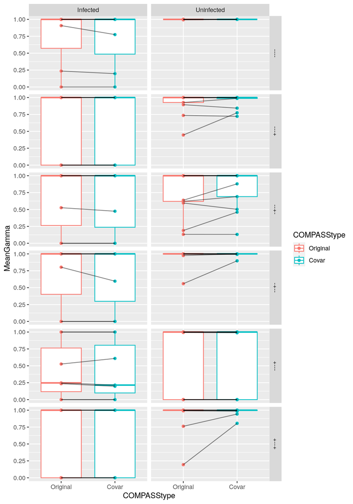

## 2.2 Patients Who Change

| TheID | Visit | event | Gate | Original | Covar |
| --- | --- | --- | --- | --- | --- |
| CTOT22-39-183 | 2 | Infected | --+- | 0.52652 | 0.47437 |
| CTOT22-39-201 | 2 | Uninfected | ---+ | 0.44552 | 0.7747 |
| CTOT22-39-202 | 2 | Uninfected | +--+ | 0.194 | 0.80554 |

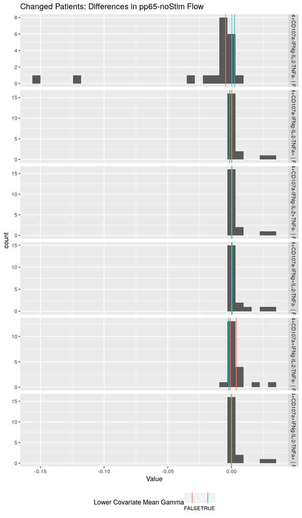

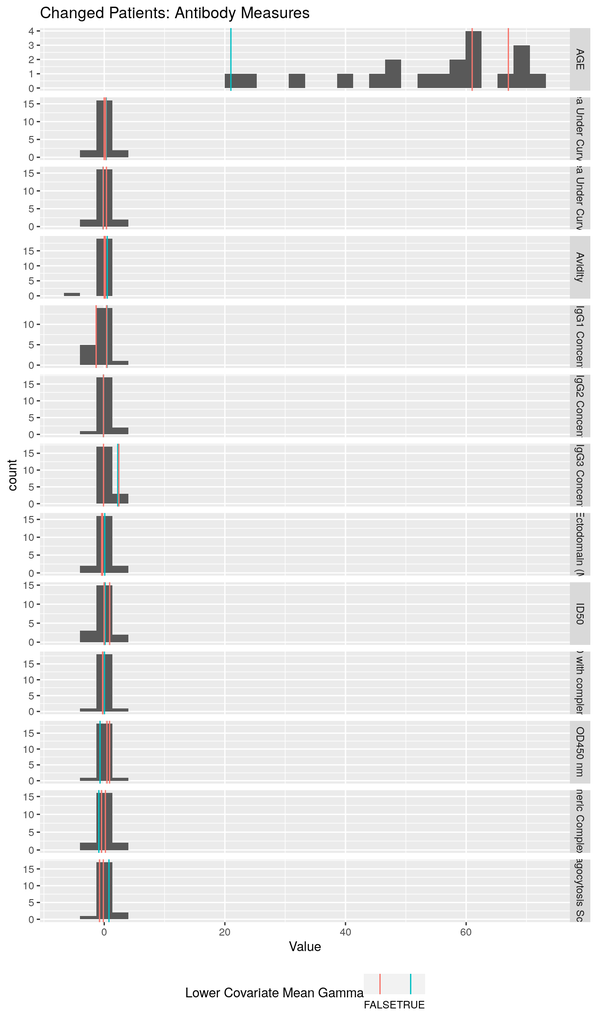

The acceptance rate for gamma for COMPASS is plotted on the below x-axis and the acceptance rate for gamma for COMPASS-covariate is plotted on the below y-axis.

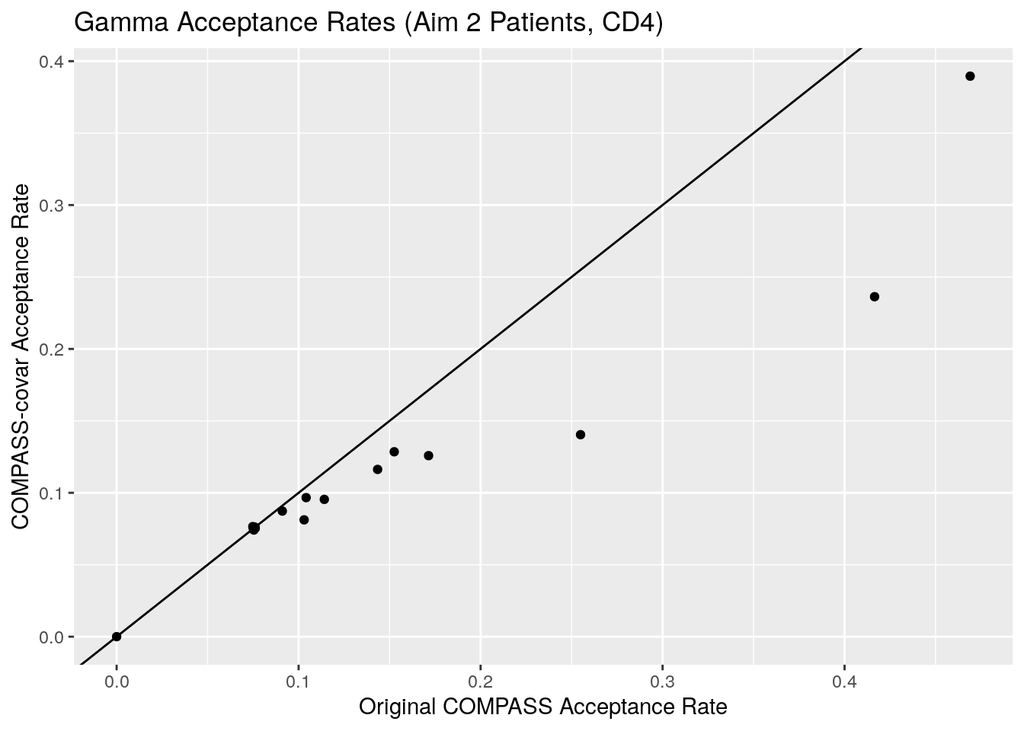

A traceplot of beta is below with a thin of 33 and the first 50% of samples excluded.

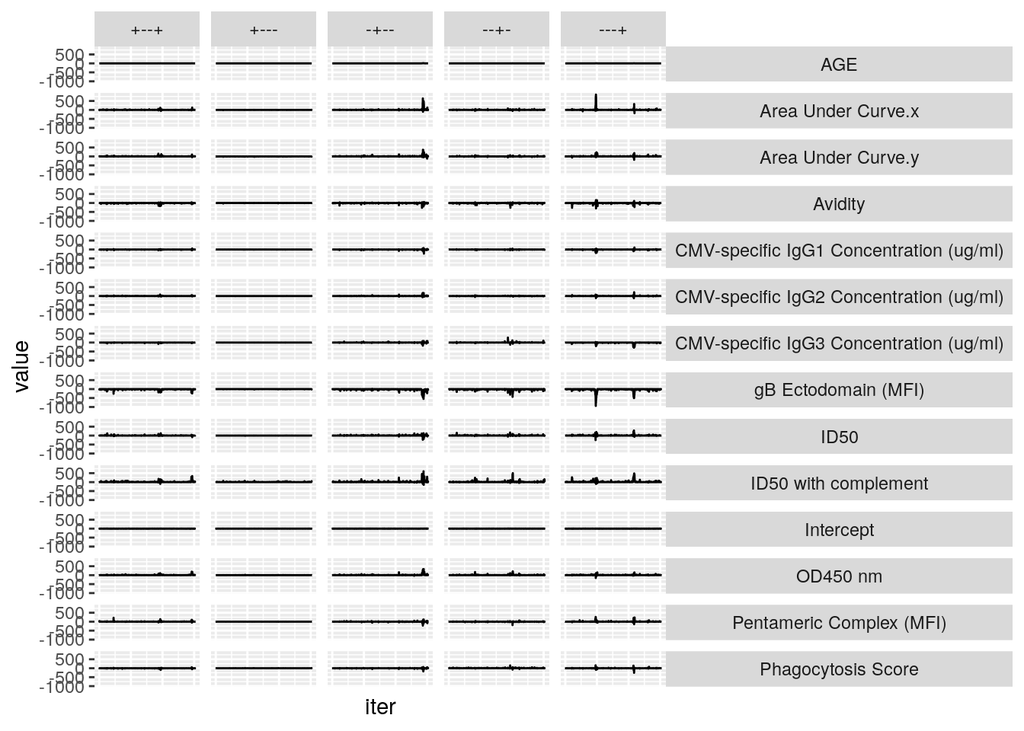

### 2.2.1 Antibody-Flow Correlation and Estimated Effects

To get an idea of whether antibodies will help in predicting gate reactivity, we do the following:

Below, we create a correlation plot of differences in proportion of cells in each gate vs. each antibody measure of interest. More colored cells indicate more that an antibody is more correlated with reaction differences in the corresponding gate.

Recall that we were wondering last time why the correlation plot of pre-transplant antibody measures with differences in proportion of cells was exactly opposite for some antibody measures compared to this one. This is caused by the different antibody measures; we look at just pre-transplant logged/scaled antibody measures before and we now look at the difference in logs between 2 to 3 months and pre-transplant antibody measures. If a pre-transplant measure is negatively correlated with expression of a gate after pp65 exposure, and the difference between 2 to 3 months and pre-transplant is positively correlated with expression, then that means the higher the 2 to 3 month antibody value, the more the estimated probability of expression is.

Underneath the correlation plot, we plot beta point estimates (the estimated effects of the antibody measures on the gamma estimates) produced by COMPASS-covariate. Formally, these are the estimated change in log-odds of gamma=1, given a 1-standard deviation increase in the antibody measure. There is a separate estimate for each gate and each antibody measure.

Note that in the effect plot, we include intercepts. These intercepts represent the estimated base log-odds of each gate reacting to pp65, so we don’t expect the actual colors to correspond between plots. We’re more likely to see similar patterns in strength of color.

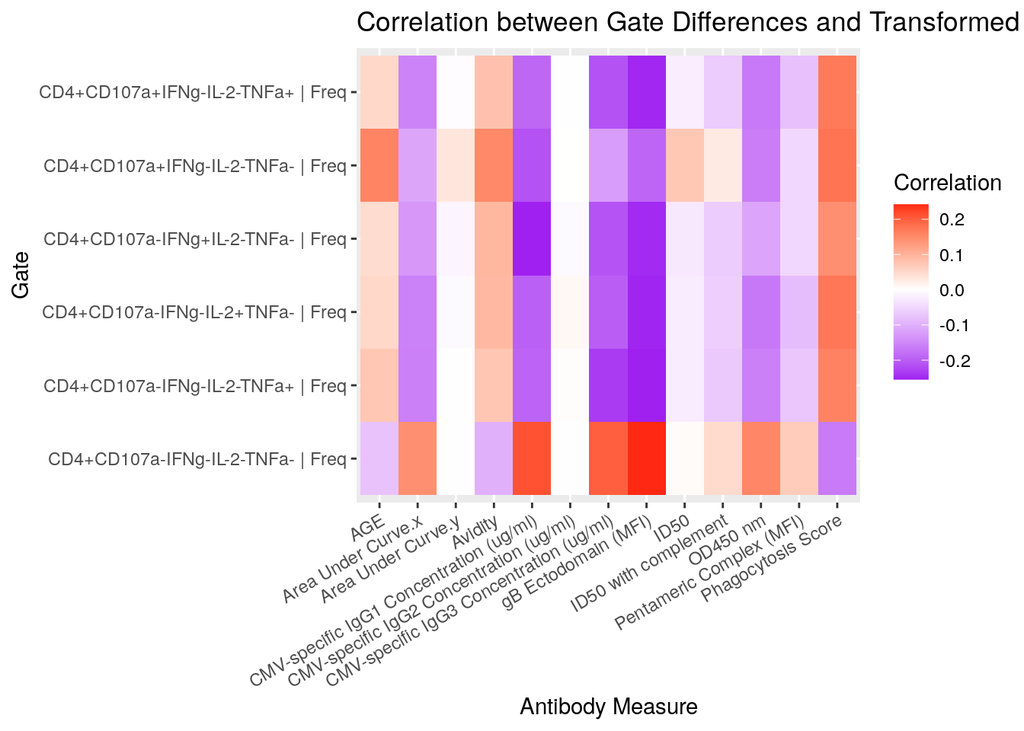

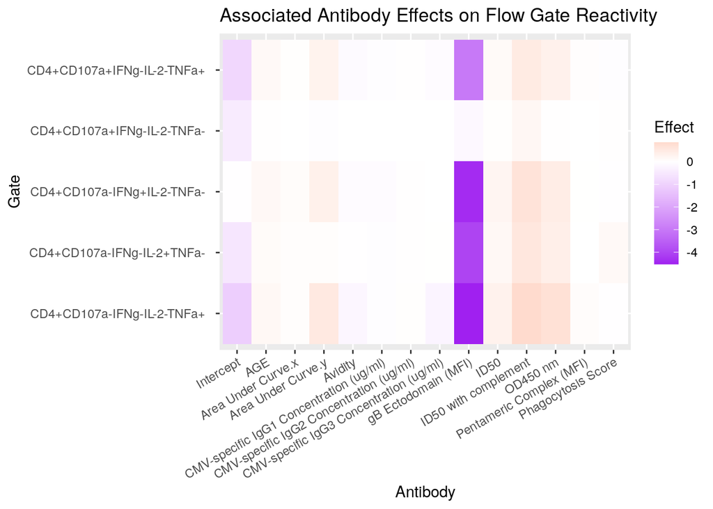

## 2.3 CD8-Only

We select only CD8 gates and further exclude gates which have less than 5 of their counts more than or equal to 2.

| ID | TheID | Visit | Stimulation | CD4-CD107a+IFNg-IL-2-TNFa- \| Count | CD4-CD107a-IFNg-IL-2+TNFa- \| Count | CD4-CD107a-IFNg-IL-2-TNFa+ \| Count | CD4-CD107a-IFNg-IL-2-TNFa- \| Count |
| --- | --- | --- | --- | --- | --- | --- | --- |
| CTOT22-19-002_2 | CTOT22-19-002 | 2 | pp65 | 48 | 21 | 0 | 11274 |
| CTOT22-19-002_2 | CTOT22-19-002 | 2 | noStim | 44 | 30 | 0 | 8979 |
| CTOT22-19-059_2 | CTOT22-19-059 | 2 | pp65 | 19 | 1 | 0 | 8370 |
| CTOT22-19-059_2 | CTOT22-19-059 | 2 | noStim | 73 | 7 | 1 | 8309 |
| CTOT22-19-065_2 | CTOT22-19-065 | 2 | pp65 | 18 | 1 | 0 | 1903 |
| CTOT22-19-065_2 | CTOT22-19-065 | 2 | noStim | 11 | 1 | 1 | 1909 |
| CTOT22-19-070_2 | CTOT22-19-070 | 2 | pp65 | 70 | 21 | 0 | 22618 |
| CTOT22-19-070_2 | CTOT22-19-070 | 2 | noStim | 25 | 33 | 0 | 19502 |
| CTOT22-21-187_2 | CTOT22-21-187 | 2 | pp65 | 3 | 0 | 0 | 669 |
| CTOT22-21-187_2 | CTOT22-21-187 | 2 | noStim | 29 | 0 | 0 | 13264 |

[output cut: 30 more lines]

### 2.3.1 Comparing Mean Gamma

The below boxplots compare the mean gamma values estimated by COMPASS-covariate and original COMPASS.

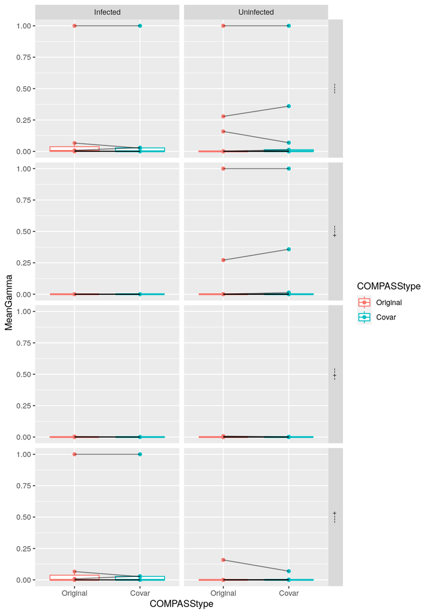

The acceptance rate for gamma for COMPASS is plotted on the below x-axis and the acceptance rate for gamma for COMPASS-covariate is plotted on the below y-axis.

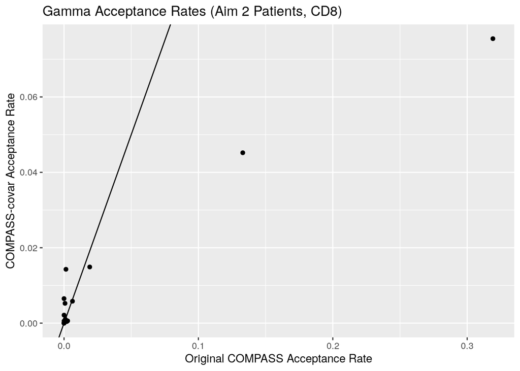

A traceplot of beta is below with a thin of 33 and the first 50% of samples excluded.

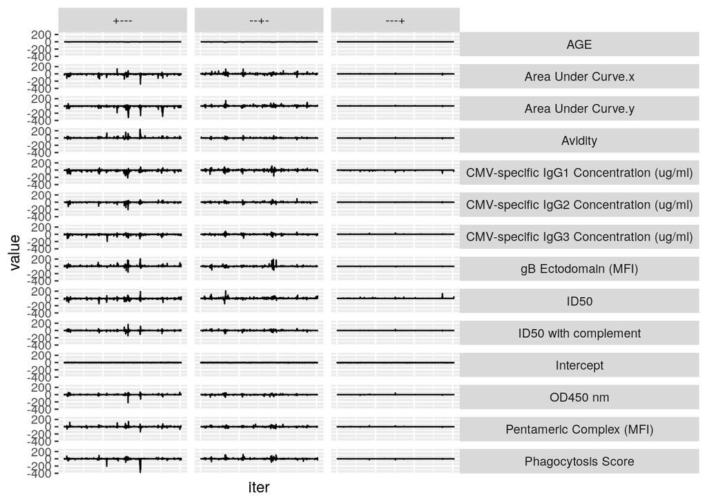

### 2.3.2 Antibody-Flow Correlation and Estimated Effects

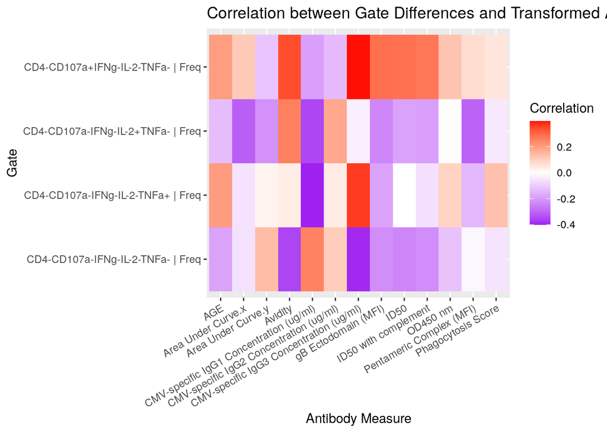

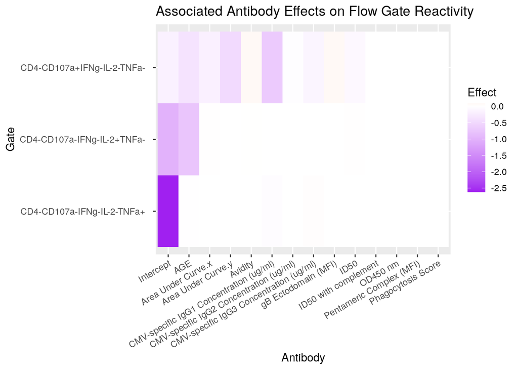

# 3 PFS/Cox Models for CD4 and CD8 Gates

We can calculate PFS scores using the CD4 and CD8-only gates with sparsity filtering. For gates that are excluded, the polyfunctional score function treats the corresponding counts as zero.

We get four sets of PFS scores:

- CD4 COMPASS original
- CD4 COMPASS covariate
- CD8 COMPASS original
- CD8 COMPASS covariate

### 3.0.1 PFS Scores

We plot these polyfunctionality scores by infection status.

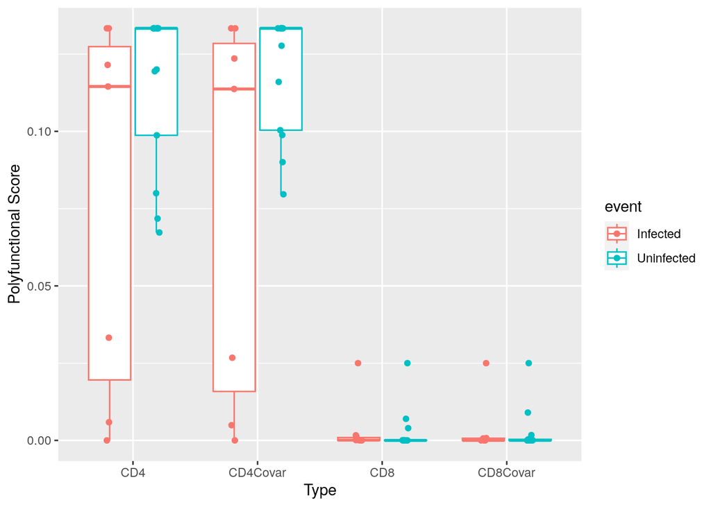

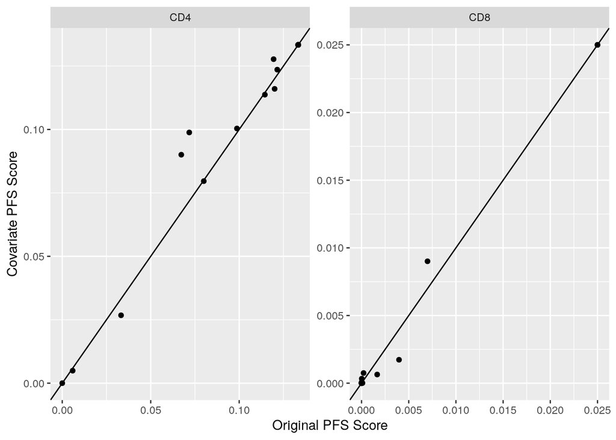

We can use these polyfunctional scores as covariates in a Cox PH model in order to model whether a patient is reinfected or not with CMV after prophylaxis stop.

|  | Coefficient | Adjusted Hazard Ratio | SE of Coefficient | P-value |
| --- | --- | --- | --- | --- |
| CD4PFS | -10.02 | 0 | 7.52 | 0.18 |
| CD8PFS | 26.56 | 343454378997.25 | 47.53 | 0.58 |
| CD4PFS-Covar | -10.67 | 0 | 7.35 | 0.15 |
| CD8PFS-Covar | 26.11 | 218431401122.03 | 47 | 0.58 |

### 3.0.2 FS Scores

We plot these functionality scores by infection status.

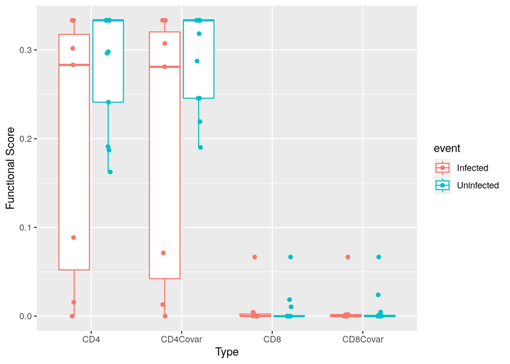

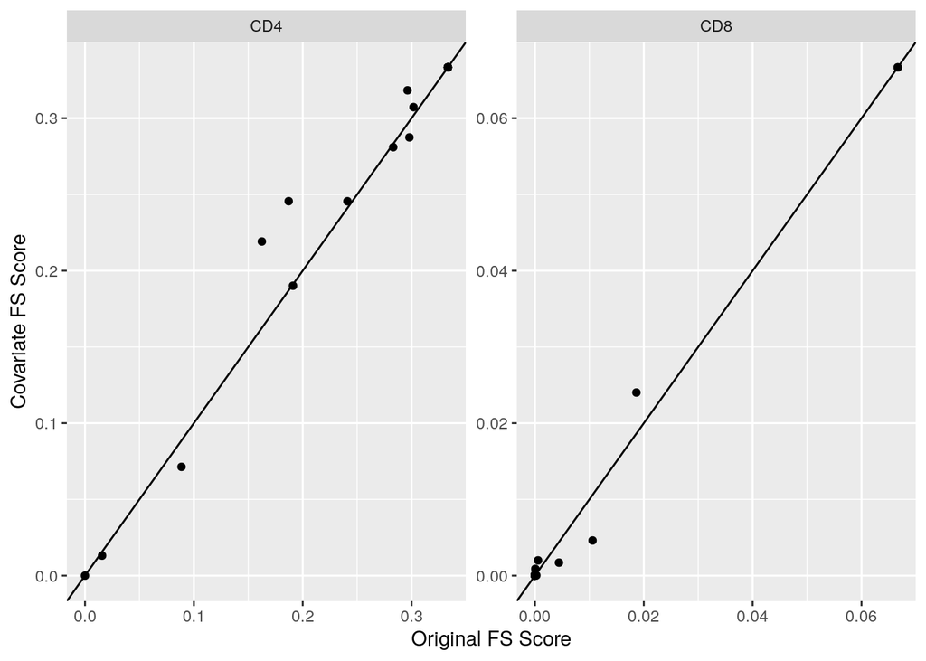

We can use these functional scores as covariates in a Cox PH model in order to model whether a patient is reinfected or not with CMV after prophylaxis stop.

|  | Coefficient | Adjusted Hazard Ratio | SE of Coefficient | P-value |
| --- | --- | --- | --- | --- |
| CD4FS | -3.91 | 0.02 | 3.04 | 0.2 |
| CD8FS | 9.96 | 21181.22 | 17.82 | 0.58 |
| CD4FS-Covar | -4.19 | 0.02 | 2.97 | 0.16 |
| CD8FS-Covar | 9.79 | 17874.88 | 17.62 | 0.58 |

### 3.0.3 Mean Gamma

We attempt to put mean gamma as covariates into the Cox model.

|  | coef | exp(coef) | se(coef) | Pr(>\|z\|) |
| --- | --- | --- | --- | --- |
| `CD4+CD107a+IFNg-IL-2-TNFa+ \| Count` | -15.5 | 0 | 367172.93 | 1 |
| `CD4+CD107a+IFNg-IL-2-TNFa- \| Count` | 0.04 | 1.04 | 1.96 | 0.98 |
| `CD4+CD107a-IFNg+IL-2-TNFa- \| Count` | -32.52 | 0 | 39463.44 | 1 |
| `CD4+CD107a-IFNg-IL-2+TNFa- \| Count` | 51.56 | 2.47680489749209e+22 | 60185.27 | 1 |
| `CD4+CD107a-IFNg-IL-2-TNFa+ \| Count` | -4.45 | 0.01 | 378040.83 | 1 |

For both covar and original COMPASS, this doesn’t yield informative results.

|  | coef | exp(coef) | se(coef) | Pr(>\|z\|) |
| --- | --- | --- | --- | --- |
| `CD4+CD107a+IFNg-IL-2-TNFa+ \| Count` | 58.39 | 2.2725945727761e+25 | 337118.62 | 1 |
| `CD4+CD107a+IFNg-IL-2-TNFa- \| Count` | 0.37 | 1.45 | 2.08 | 0.86 |
| `CD4+CD107a-IFNg+IL-2-TNFa- \| Count` | -47.89 | 0 | 66005.26 | 1 |
| `CD4+CD107a-IFNg-IL-2+TNFa- \| Count` | 62.41 | 1.27262213523431e+27 | 82900 | 1 |
| `CD4+CD107a-IFNg-IL-2-TNFa+ \| Count` | -74.06 | 0 | 350589.59 | 1 |